# A1 - Estadística Avanzada

Leroy Deniz

2022-10-14

Importación de librerías

```r
library(psych)
library(dplyr)
library(ggplot2)
library(VIM)
```

___

## 1 Carga del archivo

Se carga el contenido del fichero *gpa_row.csv* utilizando la función *read.csv* y se muestran sus primeros registros junto con los nombres de las columnas y sus tipos.

```r
df <- read.csv("gpa_row.csv", sep=",", dec='.')
print(head(df))
```

```
##    sat tothrs     hsize hsrank   hsperc colgpa athlete female white black
## 1  920    43h       0.1      4 40.00000   2.04    TRUE   TRUE FALSE FALSE
## 2 1170    18h 9.3999996    191 20.31915   4.00   FALSE  FALSE  TRUE FALSE
## 3  810    14h 1.1900001     42 35.29412   1.78    TRUE  FALSE  TRUE FALSE
## 4  940    40h      5.71    252 44.13310   2.42   FALSE  FALSE  TRUE FALSE
## 5 1180    18h 2.1400001     86 40.18692   2.61   FALSE  FALSE  TRUE FALSE
## 6  980   114h 2.6800001     41 15.29851   3.03   FALSE   TRUE  TRUE FALSE
```

```r
cat("La cantidad de registros del dataset es de", nrow(df), " con", length(df), "columnas")
```

```
## La cantidad de registros del dataset es de 4137  con 10 columnas
```

Se muestran más explícitamente los tipos de datos con los que R ha identificado cada columna, habiendo presencia de tipos enteros, numéricos (floats), lógicos y caracteres. (Para mejorar su visualización, se convierte en una matriz y se traspone)

```r
t(t(sapply(df,class)))
```

```
##         [,1]
## sat     "integer"
## tothrs  "character"
## hsize   "character"
## hsrank  "integer"
## hsperc  "numeric"
## colgpa  "numeric"
## athlete "character"
## female  "logical"
## white   "character"
## black   "character"
```

Las columnas de tipo numérico son *sat*, *tothrs*, *hsize*, *hsrank*, *hsperc* y *colgpa*, sin embargo R no ha identificado como numéricas *tothrs* y *hsize*, por lo que corresponderá aplicar la transformación más adelante.

## 2 Normalización de variables cualitativas

### 2.1 Variable *athlete*

*“athlete: indicador de si el estudiante practica algún deporte en la universidad”*

Siguiendo el criterio propuesto en el enunciado de la tarea, será convertidas a tipo *factor*, con los valores *TRUE* o *FALSE* sin espacios. Primero se verifica qué valores están presentes en esa columna.

```r
unique(df$athlete)
```

```
## [1] "TRUE"  "FALSE" "false" "true"
```

Como puede verse anteriormente, tanto *false* como *true* están en mayúsculas y minúsculas, por lo que se procede a su homogeneización en mayúsculas.

```r
df$athlete = sapply(df$athlete, toupper)
unique(df$athlete)
```

```
## [1] "TRUE"  "FALSE"
```

Se eliminan los espacios en blanco utilizando la función *trim*.

```r
df$athlete <- sapply(df$athlete, trimws, which=c("both"))
```

A continuación se convierte la columna a tipo *factor*.

```r
df$athlete <- factor(df$athlete)
```

### 2.2 Variable *female*

*“female: indicador de si el estudiante es mujer”*

Se identifican los valores presentes en la columna, que como se puede ver, son correctos.

```r
unique(df$female)
```

```
## [1]  TRUE FALSE
```

Se eliminan los espacios en blanco, si los hubiera, en ambos extremos de cada valor y se convierte la columna a factor.

```r
df$female <- sapply(df$female, trimws, which=c("both"))
df$female <- factor(df$female)
```

### 2.3 Variable *black*

*“black: indicador de si el estudiante es de raza negra o no”*

Se identifican los valores presentes en la columna, que muestra a simple vista la existencia de mayúsculas, minúsculas, y espacios en blanco.

```r
unique(df$black)
```

```
## [1] "FALSE"    "TRUE"     "  FALSE"  "FALSE   " "false"    "TRUE   "
```

Se unifican los valores a mayúsculas, se eliminan los espacios en blanco, si los hubiera, en ambos extremos de cada valor y se convierte la columna a *factor*. Al final se muestra los distintos valores que toma la variable en la columna.

```r
df$black = sapply(df$black, toupper)
df$black <- sapply(df$black, trimws, which=c("both"))
df$black <- factor(df$black)
unique(df$black)
```

```
## [1] FALSE TRUE
## Levels: FALSE TRUE
```

### 2.4 Variable *white*

*“white: indicador de si el estudiante es de raza blanca o no”*

Se identifican los valores presentes en la columna, que muestra a simple vista la existencia de mayúsculas, minúsculas, y espacios en blanco.

```r
unique(df$white)
```

```
## [1] "FALSE"   "TRUE"    "TRUE   " "true"    "false"   "  TRUE"
```

Se unifican los valores a mayúsculas, se eliminan los espacios en blanco, si los hubiera, en ambos extremos de cada valor y se convierte la columna a *factor*. Al final se muestra los distintos valores que toma la variable en la columna.

```r
df$white = sapply(df$white, toupper)
df$white <- sapply(df$white, trimws, which=c("both"))
df$white <- factor(df$white)
```

El resultado de la normalización de variables cualitativas se puede ver a continuación:

1. **Tipos de Columnas**:

```r
sapply(df[c("athlete", "female", "black", "white")], class)
```

```
##  athlete   female    black    white
## "factor" "factor" "factor" "factor"
```

2. **Contenido de estas cuatro columnas**:

```r
sapply(df[c("athlete", "female", "black", "white")], unique)
```

```
##      athlete female  black   white
## [1,] "TRUE"  "TRUE"  "FALSE" "FALSE"
## [2,] "FALSE" "FALSE" "TRUE"  "TRUE"
```

## 3 Normalización de variables cuantitativas

Antes de proceder a la normalización de las variables, se ha añadido el atributo dec=‘.’ a la función *read.csv* para tomar por defecto el punto como separador de decimales.

### 3.1 Variable *sat*

*“sat: nota de acceso (medida en escala de 400 a 1600 puntos)”*

Según el criterio de normalización establecido, primero habría que realizar el cambio del separador decimal al punto, sin embargo la columna fue identificada por R como *integer*, lo que nos asegura que son todos números enteros y por lo tanto que no tienen punto decimal, así como tampoco unidad de medida, puesto que en ese caso tendríamos una columna de tipo *character*.

Se verifica a continuación que el rango en el que oscilan los valores de la columna *sat* está incluido en el intervalo [400,1600].

```r
range(df$sat)
```

```
## [1]  470 1540
```

### 3.2 Variable *tothrs*

*“tothrs: horas totales cursadas en el semestre”*

El tipo de esta clase es *character*, por lo que es probable encontrar unidades en los valores o caracteres no numéricos, a lo que habrá que aplicar un cambio que modifique el contenido por el valor numérico asociado.

```r
unique(df$tothrs)
```

```
##   [1] "43h"  "18h"  "14h"  "40h"  "114h" "78h"  "55h"  "17h"  "64h"  "45h"
##  [11] "41h"  "13h"  "110h" "106h" "104h" "115h" "96h"  "50h"  "100h" "112h"
##  [21] "39h"  "118h" "46h"  "12h"  "85h"  "42h"  "16h"  "71h"  "19h"  "47h"
##  [31] "103h" "105h" "72h"  "15h"  "38h"  "29h"  "79h"  "37h"  "113h" "48h"
##  [41] "95h"  "86h"  "83h"  "53h"  "63h"  "122h" "20h"  "54h"  "81h"  "76h"
##  [51] "52h"  "77h"  "87h"  "49h"  "36h"  "74h"  "80h"  "73h"  "108h" "35h"
##  [61] "107h" "102h" "44h"  "92h"  "94h"  "117h" "69h"  "93h"  "75h"  "32h"
##  [71] "11h"  "116h" "126h" "70h"  "58h"  "127h" "90h"  "97h"  "84h"  "129h"
##  [81] "57h"  "125h" "10h"  "82h"  "111h" "62h"  "88h"  "98h"  "121h" "89h"
##  [91] "51h"  "120h" "131h" "123h" "91h"  "21h"  "119h" "133h" "109h" "23h"
## [101] "59h"  "99h"  "134h" "66h"  "68h"  "67h"  "124h" "65h"  "61h"  "101h"
## [111] "56h"  "60h"  "22h"  "137h" "6h"   "132h" "30h"  "128h" "24h"  "34h"
## [121] "33h"  "136h" "28h"  "130h" "9h"
```

Tal y como se ve anteriormente, hará falta quitar la unidad de horas (‘h’) al final de cada valor previo a la conversión de la columna.

```r
df$tothrs = substr(df$tothrs,1,nchar(df$tothrs)-1)
unique(df$tothrs)
```

```
##   [1] "43"  "18"  "14"  "40"  "114" "78"  "55"  "17"  "64"  "45"  "41"  "13"
##  [13] "110" "106" "104" "115" "96"  "50"  "100" "112" "39"  "118" "46"  "12"
##  [25] "85"  "42"  "16"  "71"  "19"  "47"  "103" "105" "72"  "15"  "38"  "29"
##  [37] "79"  "37"  "113" "48"  "95"  "86"  "83"  "53"  "63"  "122" "20"  "54"
##  [49] "81"  "76"  "52"  "77"  "87"  "49"  "36"  "74"  "80"  "73"  "108" "35"
##  [61] "107" "102" "44"  "92"  "94"  "117" "69"  "93"  "75"  "32"  "11"  "116"
##  [73] "126" "70"  "58"  "127" "90"  "97"  "84"  "129" "57"  "125" "10"  "82"
##  [85] "111" "62"  "88"  "98"  "121" "89"  "51"  "120" "131" "123" "91"  "21"
##  [97] "119" "133" "109" "23"  "59"  "99"  "134" "66"  "68"  "67"  "124" "65"
## [109] "61"  "101" "56"  "60"  "22"  "137" "6"   "132" "30"  "128" "24"  "34"
## [121] "33"  "136" "28"  "130" "9"
```

Se convierte la columna a tipo numérico, puesto que son todos números enteros también podría ser *integer*.

```r
df$tothrs = as.numeric(df$tothrs)
```

### 3.3 Variable *colgpa*

*“colgpa: nota media del estudiante al final del primer semestre (medida en escala de 0 a 4 puntos)”*

El tipo de *colgpa* ya es tipo numérico tal como lo auto-identificó R y con la instrucción *dec*, que se definió en la lectura del csv, queda asegurado que el separador de decimales es correcto; por lo que resta proceder a verificar que todos sus elementos están dentro del rango [0-4]. En al siguiente instrucción se contabilizan todos todas las apariciones fuera de este intervalo.

```r
sum(df[which(df$colgpa<0)] | df[which(df$colgpa>4)])
```

```
## [1] 0
```

### 3.4 Variable *hsize*

*“hsize: numero total de estudiantes en la cohorte de graduados del bachillerato (en cientos)”*

```r
x_nonum <- which(is.na(suppressWarnings(as.numeric(df$hsize))))
df$hsize[x_nonum]
```

```
##  [1] "2,54"       "0,73000002" "2,6099999"  "5,6300001"  "2,55"
##  [6] "5,1100001"  "4,71"       "2,6199999"  "1,8"        "3,79"
## [11] "1,55"       "3,4000001"  "0,30000001" "1,86"       "2,7"
## [16] "1,15"       "1,92"       "2,4000001"  "0,40000001" "3,24"
## [21] "3,3299999"  "6,0999999"  "1,63"       "3,02"
```

Como se puede ver en el bloque anterior, algunos elementos no son considerados numéricos por el separador de decimales, por lo que se cambia la coma por punto en esos casos puntuales.

Referencia del código en este [link](https://rpubs.com/juliosergio/98086).

```r
# Realizamos la sustitución de las comas por puntos en los casos problemáticos
df$hsize <- sub(",", ".", df$hsize, fixed=TRUE)
```

Se verifican cuántos de los casos no son numéricos, igual que hicimos en el paso anterior y la respuesta es 0

```r
x_nonum <- which(is.na(suppressWarnings(as.numeric(df$hsize))))
df$hsize[x_nonum]
```

```
## character(0)
```

Se convierte la columna a tipo numérico y se verifica el nuevo tipo.

```r
df$hsize = as.numeric(df$hsize)
sapply(df[c("hsize")], class)
```

```
##     hsize
## "numeric"
```

### 3.5 Variable *hsperc*

*“hsperc: ranking relativo del estudiante (hsrank/hsize)”*

El tipo de *hsperc* es tipo numérico, por lo que se puede descartar que existan el esta columna valores que no lo sean, como las unidades, además de tener como separador de decimales el punto para que estos seas correctamente tratados.

Resta entonces asegurar que el valor que contiene la columna *hsperc* se corresponde al ratio entre *hsrank* y *hsize*.

```r
same_values <- length(which(df$hsperc == df$hsrank/df$hsize))
diff_values <- length(which(df$hsperc != df$hsrank/df$hsize))


cat("Iguales:\t", same_values, "\nDistintos:\t",diff_values)
```

```
## Iguales:  317
## Distintos:    3820
```

Se aplica la transformación a todos los registros puesto que son más lo que son distintos que los que son iguales, y se verifica nuevamente.

```r
df$hsperc <- df$hsrank/df$hsize

same_values <- length(which(df$hsperc == df$hsrank/df$hsize))
diff_values <- length(which(df$hsperc != df$hsrank/df$hsize))


cat("Iguales:\t", same_values, "\nDistintos:\t",diff_values)
```

```
## Iguales:  4137
## Distintos:    0
```

Como resultado del proceso de normalización, aquí se presentan los tipos de cada una de las columnas que componen en dataset

```r
t(t(sapply(df,class)))
```

```
##         [,1]
## sat     "integer"
## tothrs  "numeric"
## hsize   "numeric"
## hsrank  "integer"
## hsperc  "numeric"
## colgpa  "numeric"
## athlete "factor"
## female  "factor"
## white   "factor"
## black   "factor"
```

## 4 Valores atípicos

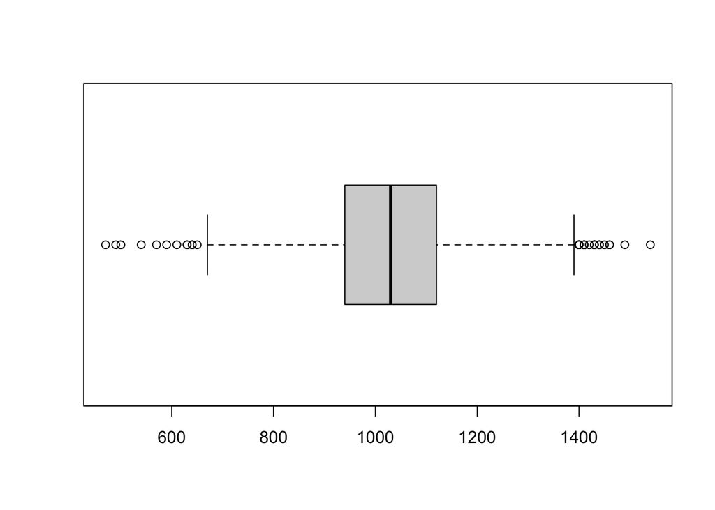

```r
boxplot(df$sat, horizontal = TRUE)
```

Los estadísticos que se definen desde el boxplot son los siguientes:

```r
summary(df$sat)
```

```
##    Min. 1st Qu.  Median    Mean 3rd Qu.    Max.
##     470     940    1030    1030    1120    1540
```

Se guardan los registros de estos *outliers* en la variable homónima.

```r
outliers = boxplot.stats(df$sat)$out
cat("Hay un total de", length(outliers), "outliers")
```

```
## Hay un total de 39 outliers
```

Se asigna NA a todos los 39 outliers identificados, por lo que ahora aparecen en los datos del boxplot.

```r
df$sat[which(df$sat %in% outliers)] = NaN
summary(df$sat)
```

```
##    Min. 1st Qu.  Median    Mean 3rd Qu.    Max.    NA's
##     670     940    1020    1029    1120    1390      39
```

Se realiza el mismo procedimiento para la variable *hsize*, utilizando un boxplot para detectar la presencia de outliers.

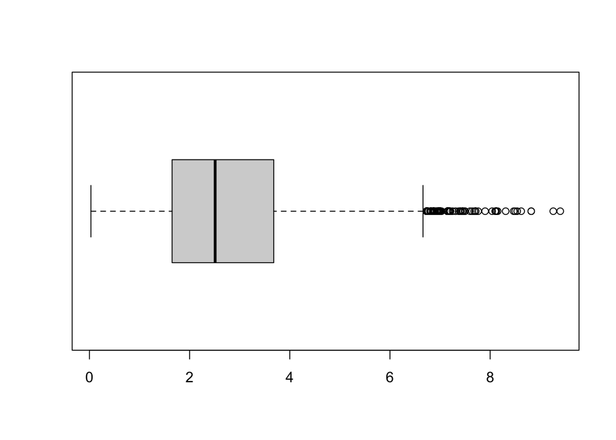

```r
boxplot(df$hsize, horizontal = TRUE)
```

Información del boxplot.

```r
summary(df$hsize)
```

```
##    Min. 1st Qu.  Median    Mean 3rd Qu.    Max.
##    0.03    1.65    2.51    2.80    3.68    9.40
```

Se guardan los outliers en un vector.

```r
outliers = boxplot.stats(df$hsize)$out
cat("Hay un total de", length(outliers), "outliers")
```

```
## Hay un total de 169 outliers
```

Se le asigna *NA* a los outliers encontrados y ahora se muestran dentro de los datos estadísticos.

```r
df$hsize[which(df$hsize %in% outliers)] = NaN
summary(df$hsize)
```

```
##    Min. 1st Qu.  Median    Mean 3rd Qu.    Max.    NA's
##   0.030   1.600   2.440   2.612   3.450   6.660     169
```

## 5 Imputación de valores

Si se da un vistazo rápido al dataset con la función *summary*, se puede observar que las columnas *sat*, *hsize* y *colgpa* contienen valores *NA*, 39, 169 y 41 respectivamente.

```r
summary(df)
```

```
##       sat           tothrs           hsize           hsrank
##  Min.   : 670   Min.   :  6.00   Min.   :0.030   Min.   :  1.00
##  1st Qu.: 940   1st Qu.: 17.00   1st Qu.:1.600   1st Qu.: 11.00
##  Median :1020   Median : 47.00   Median :2.440   Median : 30.00
##  Mean   :1029   Mean   : 52.83   Mean   :2.612   Mean   : 52.83
##  3rd Qu.:1120   3rd Qu.: 80.00   3rd Qu.:3.450   3rd Qu.: 70.00
##  Max.   :1390   Max.   :137.00   Max.   :6.660   Max.   :634.00
##  NA's   :39                      NA's   :169
##      hsperc            colgpa       athlete       female       white
##  Min.   : 0.1667   Min.   :0.000   FALSE:3943   FALSE:2277   FALSE: 308
##  1st Qu.: 6.4328   1st Qu.:2.210   TRUE : 194   TRUE :1860   TRUE :3829
##  Median :14.5833   Median :2.660
##  Mean   :19.2371   Mean   :2.655
##  3rd Qu.:27.7108   3rd Qu.:3.120
##  Max.   :92.0000   Max.   :4.000
##                    NA's   :41
##    black
##  FALSE:3908
##  TRUE : 229
##
##
##
##
##
```

Se identifican los valores faltantes utilizando *filter*.

```r
nans <- filter(df, is.na(sat) | is.na(hsize) | is.na(colgpa))
head(nans)
```

```
##    sat tothrs hsize hsrank     hsperc colgpa athlete female white black
## 1 1170     18   NaN    191 20.3191498   4.00   FALSE  FALSE  TRUE FALSE
## 2 1200     39   NaN    209 25.7389166   2.38   FALSE   TRUE  TRUE FALSE
## 3  940     19  1.85     41 22.1621622     NA   FALSE  FALSE  TRUE FALSE
## 4  NaN     85  2.30      1  0.4347826   4.00   FALSE  FALSE  TRUE FALSE
## 5  NaN     14  4.57    329 71.9912441   1.21    TRUE  FALSE  TRUE FALSE
## 6  NaN     79  3.24    187 57.7160494   1.73    TRUE  FALSE FALSE  TRUE
```

Se aplica un *kNN* de k=11 condicionado al género, unificando posteriormente los nuevos valores con el dataset original, y puede verse a través de *summary* que ya no hay presencia de valores *NA*.

```r
df_female = kNN(dplyr::filter(df, female == TRUE), variable = c('sat', 'hsize', 'colgpa'), dist_var = c('sat', 'tothrs',  'hsize','hsrank', 'hsperc', 'colgpa'), k = 11, catFun = gowerD)
df_not_female = kNN(dplyr::filter(df, female == FALSE), variable = c('sat', 'hsize', 'colgpa'), dist_var = c('sat', 'tothrs',  'hsize', 'hsrank', 'hsperc', 'colgpa'), k = 11, catFun = gowerD)
df = rbind(df_female,df_not_female)
df = within(df, rm('sat_imp', 'hsize_imp', 'colgpa_imp'))
summary(df)
```

```
##       sat           tothrs           hsize           hsrank
##  Min.   : 670   Min.   :  6.00   Min.   :0.030   Min.   :  1.00
##  1st Qu.: 940   1st Qu.: 17.00   1st Qu.:1.650   1st Qu.: 11.00
##  Median :1030   Median : 47.00   Median :2.510   Median : 30.00
##  Mean   :1030   Mean   : 52.83   Mean   :2.673   Mean   : 52.83
##  3rd Qu.:1120   3rd Qu.: 80.00   3rd Qu.:3.600   3rd Qu.: 70.00
##  Max.   :1390   Max.   :137.00   Max.   :6.660   Max.   :634.00
##      hsperc            colgpa       athlete       female       white
##  Min.   : 0.1667   Min.   :0.000   FALSE:3943   FALSE:2277   FALSE: 308
##  1st Qu.: 6.4328   1st Qu.:2.210   TRUE : 194   TRUE :1860   TRUE :3829
##  Median :14.5833   Median :2.660
##  Mean   :19.2371   Mean   :2.654
##  3rd Qu.:27.7108   3rd Qu.:3.120
##  Max.   :92.0000   Max.   :4.000
##    black
##  FALSE:3908
##  TRUE : 229
##
##
##
##
```

Se puede confirmar además aplicando un filtro que nos devuelva todos los valores *NA* del dataset, que como puede verse en el resultado, es vacío.

```r
filter(df, is.na(sat) | is.na(hsize) | is.na(colgpa))
```

```
##  [1] sat     tothrs  hsize   hsrank  hsperc  colgpa  athlete female  white
## [10] black
## <0 rows> (or 0-length row.names)
```

## 6 Creación de una variable

Se utiliza la función *cut*, definiendo los puntos de corte ( *breaks* ) entre los intervalos y las etiquetas que se asignan a cada uno ( *labels* ).

Referencia del código en este [link](https://r-coder.com/categorizar-variables-r/).

```r
gpaletter <- cut (df$colgpa, breaks=c(0, 1.49, 2.49, 3.49, 4.0), labels=c("D", "C", "B", "A") )

table(gpaletter)
```

```
## gpaletter
##    D    C    B    A
##  142 1540 1995  458
```

Finalmente, se añade este vector al dataset original en forma de columna utilizando *cbind*.

```r
df <- cbind(df, gpaletter=gpaletter)
t(t(sapply(df,class)))
```

```
##           [,1]
## sat       "numeric"
## tothrs    "numeric"
## hsize     "numeric"
## hsrank    "integer"
## hsperc    "numeric"
## colgpa    "numeric"
## athlete   "factor"
## female    "factor"
## white     "factor"
## black     "factor"
## gpaletter "factor"
```

## 7 Estudio descriptivo

### 7.1 Estudio descriptivo de las variables cualitativas

**Primer gráfico**: Representación gráfica utilizando gplot de la variable *athlete* en porcentajes.

Referencia del código en este [link](https://www.youtube.com/watch?v=4DpktFAluCY).

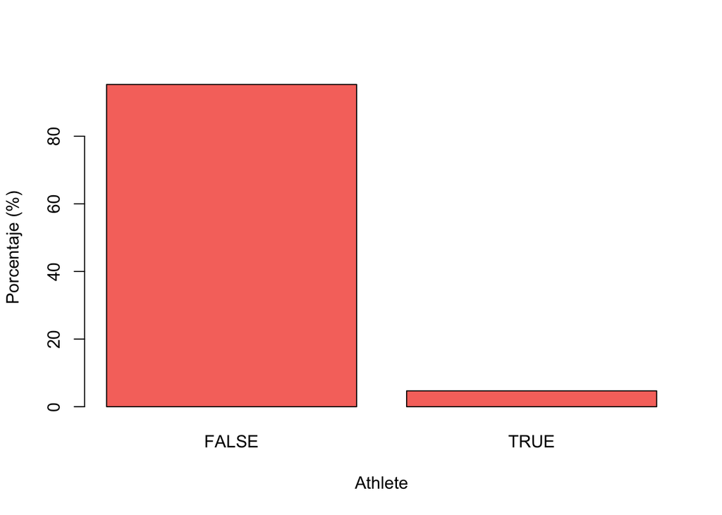

```r
data_perc <- t(prop.table(table(df$athlete)))
barplot(data_perc*100, col='#F7766C', xlab="Athlete", ylab="Porcentaje (%)")
```

El gráfico está relacionado con los valores que presenta la variable, como se muestra a continuación en porcentajes:

```r
100*table(df$athlete)/length(df$athlete)
```

```
##
##     FALSE      TRUE
## 95.310612  4.689388
```

**Segundo gráfico**: variable *athlete* en función del sexo ( *female* ) donde se muestre visualmente si el porcentaje de hombres y mujeres cambia al ser atleta o no.

Se empieza por calcular los porcentajes asociados a las combinaciones en función del 100% de los casos por género.

```r
options(dplyr.summarise.inform = FALSE) # Evita un warning de summarize
perc_table <- df %>%
  group_by(athlete, female) %>%
    dplyr::summarize(count = n()) %>%
      mutate(perc = count/sum(count))

perc_table
```

```
## # A tibble: 4 × 4
## # Groups:   athlete [2]
##   athlete female count  perc
##   <fct>   <fct>  <int> <dbl>
## 1 FALSE   FALSE   2128 0.540
## 2 FALSE   TRUE    1815 0.460
## 3 TRUE    FALSE    149 0.768
## 4 TRUE    TRUE      45 0.232
```

Referencia de eliminación del warning de *summarize* en el siguiente [link](https://statisticsglobe.com/dplyr-message-summarise-has-grouped-output-r).

Se dibuja un gráfico de barras que representa la distribución de género según si son, o no, atletas.

Referencia del código en este [link](https://stackoverflow.com/questions/24776200/ggplot-replace-count-with-percentage-in-geom-bar).

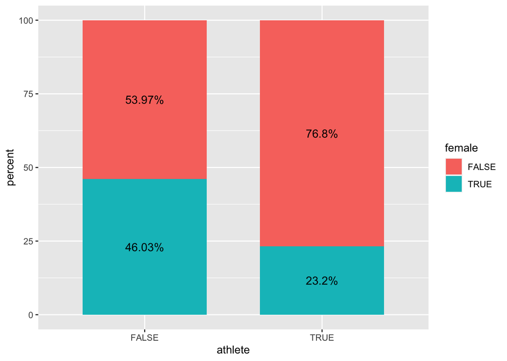

```r
ggplot(perc_table, aes(x = athlete, y = perc*100, fill = factor(female))) +
  geom_bar(stat="identity", width = 0.7) +
  labs(x = "athlete", y = "percent", fill = "female") +
  geom_text(data=perc_table, position = position_stack(vjust = 0.5), aes(x=athlete, y=perc*100, label = paste0(round(perc*100, digits=2),"%")), size=4)
```

En el gráfico anterior se puede ver que aquellos estudiantes que no son atletas, tienden a estar prácticamente igualados entre hombres y mujeres, con apenas un poco más de hombres que no lo son. Sin embargo, aquellos que sí son atletas, algo más de las 3/4 partes son hombres.

### 7.2 Estudio descriptivo de las variables cuantitativas

- [Referencia de medidas de centralización robustas en este](https://anestesiar.org/2014/una-familia-muy-robusta-medidas-de-centralizacion-robustas/#:~:text=Existen%20una%20serie%20de%20medidas,%2C%20185%2C%20426%20y%20435.)
- [Otras medidas descriptivas usuales](https://ocw.uniovi.es/pluginfile.php/3939/mod_label/intro/1C_C6587/materia_de_clase/Tema7_EAI_teoria.pdf)
- [Estadísticos y gráficos con el lenguaje R](https://www.uv.es/mperea/r_ejemplo.htm)

Se crea una tabla para mostrar la información calculada. En el cálculo de las medidas, se redondean los valores a 3 dígitos decimales para facilitar su lectura en la tabla.

```r
tab <- matrix ( rep (NaN, times = 0 ), ncol = 4 , byrow = TRUE ) # Se define la matriz que se va a cargar con la información de las medidas
colnames (tab) <- c (' sat ', ' tothrs ', ' hsize ', ' hsrank ')
```

- Cálculo de la **Mediana**:

```r
sat_median <- round(median(df$sat), digits=3)
tothrs_median <- round(median(df$tothrs), digits=3)
hsize_median <- round(median(df$hsize), digits=3)
hsrank_median <- round(median(df$hsrank), digits=3)
```

- Cálculo de la **Media aritmética**:

```r
sat_mean <- round(mean(df$sat), digits=3)
tothrs_mean <- round(mean(df$tothrs), digits=3)
hsize_mean <- round(mean(df$hsize), digits=3)
hsrank_mean <- round(mean(df$hsrank), digits=3)
```

- Cálculo de la **Media recortada al 5%**:

```r
sat_mean_trim_5p <- round(mean(df$sat, trim=5/100), digits=3)
tothrs_mean_trim_5p <- round(mean(df$tothrs, trim=5/100), digits=3)
hsize_mean_trim_5p <- round(mean(df$hsize, trim=5/100), digits=3)
hsrank_mean_trim_5p <- round(mean(df$hsrank, trim=5/100), digits=3)
```

- Cálculo de la **Media recortada al 10%**:

```r
sat_mean_trim_10p <- round(mean(df$sat, trim=10/100), digits=3)
tothrs_mean_trim_10p <- round(mean(df$tothrs, trim=10/100), digits=3)
hsize_mean_trim_10p <- round(mean(df$hsize, trim=10/100), digits=3)
hsrank_mean_trim_10p <- round(mean(df$hsrank, trim=10/100), digits=3)
```

- Cálculo de la **Varianza**:

```r
sat_variance <- round(var(df$sat), digits=3)
tothrs_variance <- round(var(df$tothrs), digits=3)
hsize_variance <- round(var(df$hsize), digits=3)
hsrank_variance <- round(var(df$hsrank), digits=3)
```

- Cálculo de la **Desviación estándar**:

```r
sat_sd <- round(sd(df$sat), digits=3)
tothrs_sd <- round(sd(df$tothrs), digits=3)
hsize_sd <- round(sd(df$hsize), digits=3)
hsrank_sd <- round(sd(df$hsrank), digits=3)
```

- Cálculo de la **Desviación media**:

```r
sat_dm <- round(sum(abs(df$sat-mean(df$sat)))/length(df$sat), digits=3)
tothrs_dm <- round(sum(abs(df$tothrs-mean(df$tothrs)))/length(df$tothrs), digits=3)
hsize_dm <- round(sum(abs(df$hsize-mean(df$hsize)))/length(df$hsize), digits=3)
hsrank_dm <- round(sum(abs(df$hsrank-mean(df$hsrank)))/length(df$hsrank), digits=3)
```

- Cálculo del **Rango**:

```r
sat_range <- round(range(df$sat), digits=3)
tothrs_range <- round(range(df$tothrs), digits=3)
hsize_range <- round(range(df$hsize), digits=3)
hsrank_range <- round(range(df$hsrank), digits=3)
```

Se añaden los valores a la tabla por filas según su variable

```r
tab <- rbind(tab, "Mediana"=c(sat_median, tothrs_median, hsize_median, hsrank_median))
tab <- rbind(tab, "Media aritmética"=c(sat_mean, tothrs_mean, hsize_mean, hsrank_mean))
tab <- rbind(tab, "Media recortada (5%)"=c(sat_mean_trim_5p, tothrs_mean_trim_5p, hsize_mean_trim_5p, hsrank_mean_trim_5p))
tab <- rbind(tab, "Media recortada (10%)"=c(sat_mean_trim_10p, tothrs_mean_trim_10p, hsize_mean_trim_10p, hsrank_mean_trim_10p))
tab <- rbind(tab, "Varianza"=c(sat_variance, tothrs_variance, hsize_variance, hsrank_variance))
tab <- rbind(tab, "Desv. estándar"=c(sat_sd, tothrs_sd, hsize_sd, hsrank_sd))
tab <- rbind(tab, "Desv. media"=c(sat_dm, tothrs_dm, hsize_dm, hsrank_dm))
tab <- rbind(tab, "Rango"=c(paste(sat_range,collapse="-"), paste(tothrs_range,collapse="-"), paste(hsize_range,collapse="-"), paste(hsrank_range,collapse="-")))
```

Se presenta la tabla con los valores obtenidos.

```r
tab <- as.table (tab) # Se convierte de matriz a tabla
print(tab)
```

```
##                        sat      tothrs   hsize     hsrank
## Mediana               1030     47       2.51      30
## Media aritmética      1030.191 52.832   2.673     52.83
## Media recortada (5%)  1029.538 51.271   2.631     43.994
## Media recortada (10%) 1029.061 49.757   2.6       39.896
## Varianza              17911.11 1248.18  2.313     4183.966
## Desv. estándar        133.832  35.33    1.521     64.684
## Desv. media           106.907  30.088   1.208     44.776
## Rango                 670-1390 6-137    0.03-6.66 1-634
```

Representación gráfica de la distribución de la variable *sat* mediante un histograma.

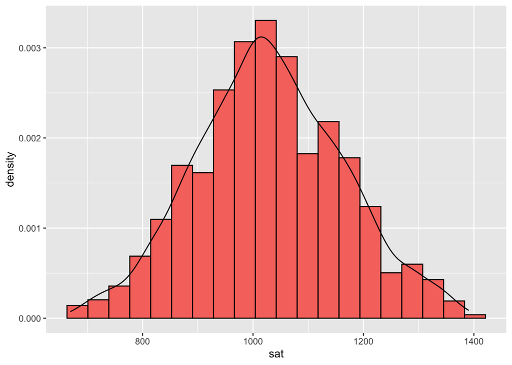

```r
ggplot(df, aes(sat)) +
  geom_histogram(aes(y = ..density..), bins = 20, color = "black", fill ="#F7766C")+
  geom_density(aes(fill = sat), alpha = 0.2)
```

Este segundo gráfico muestra la distribución de la variable *sat* en función de *female*.

Referencia del código en este [link](https://stackoverflow.com/questions/61429417/how-to-plot-multiple-distributions-with-ggplot).

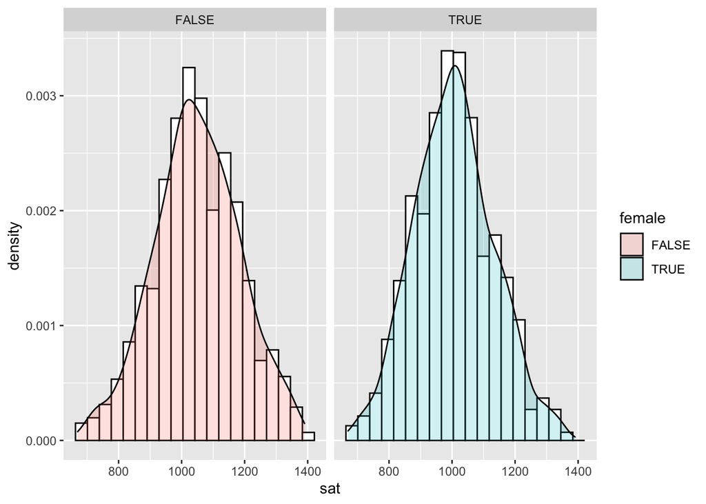

```r
ggplot(df, aes(sat)) +
  geom_histogram(aes(y = ..density..), bins = 20, color = "black", fill ="white") +
  geom_density(aes(fill = female), alpha = 0.2) +
  facet_wrap(~ female)
```

## 8 Archivo final

Se exporta el fichero *csv* con los datos procesados.

```r
write.csv2(df,file="gpa_clean.csv")
```

```r
cat("La cantidad de registros del dataset al finalizar es de", nrow(df), " con", length(df), "columnas")
```

```
## La cantidad de registros del dataset al finalizar es de 4137  con 11 columnas
```

La estructura de columnas del dataset:

```r
t(t(sapply(df,class)))
```

```
##           [,1]
## sat       "numeric"
## tothrs    "numeric"
## hsize     "numeric"
## hsrank    "integer"
## hsperc    "numeric"
## colgpa    "numeric"
## athlete   "factor"
## female    "factor"
## white     "factor"
## black     "factor"
## gpaletter "factor"
```

___

## 9 Informe ejecutivo

### 9.1 Tabla de resumen del preprocesamiento

[output not shown]

### 9.2 Resumen estadístico

El resultado del preprocesado de los datos ofrece cierta información respecto de las variables que se consideran en el dataset, como por ejemplo en la variable *sat*, la media y la mediana prácticamente del mismo valor a pesar de aplicar cuatro medidas de medias distintas; en la gráfica posterior, puede verse que podría tender a una distribución normal aunque para esto habría que eventualmente aplicar ciertos tests que no son pedidos en el enunciado.

Los datos presentan también un balanceo respecto a las variables *athlete* y *female* cuando la primera es FALSE, teniendo un desbalanceo de un 75-25 con superioridad de female=FALSE cuando *athletes* es TRUE. Esto es importante de cara a futuro si con estos datos se fueran a entrenar modelos, puesto que hay menos con qué aprender este segundo caso y, por con apenas el 5% que lo cumplen, habría un sesgo importante en un supuesto clasificador.

En función del segundo gráfico del punto 7.2, podemos decir que, aunque las distribuciones de *sat* respecto de la variable *female* son relativamente similares, aunque sí la media de famale=FALSE es mayor puesto que concentra mayor cantidad de casos en ese punto.